# Summer Fall Habitat Action Report Template

Juan De La Torre

2023-06-19

# CDEC flow data and figures

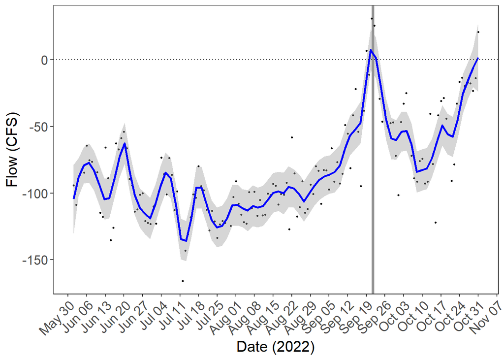

```r
fig_34_plot
```

## Figure 34

Figure 34: CDEC flow data from Lisbon Weir in the Yolo Bypass Toe Drain (station LIS) from June 1st through October 31st, 2022, taken at 15-minute intervals. Blue line indicates LOESS smoothing line ± 1 SE of daily average flow. Points represent daily average flow, the horizontal dashed line at 0 CFS indicate the threshold for positive flow (downstream), and the grey box highlights the two-day non-managed flow pulse that occurred September 21st and September 22, 2022, during which daily average flow was 31.1 CFS. Data from CDEC are provisional, did not undergo QA/QC and are subject to change.

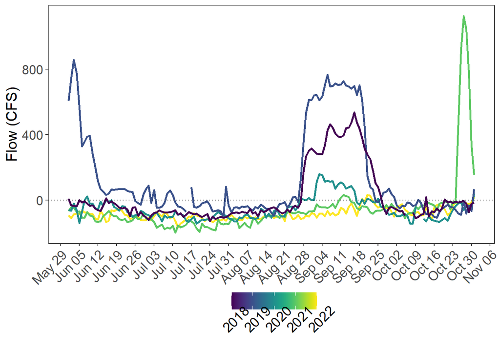

```r
fig_35_plot
```

## Figure 35